# Why R² Isn’t Enough

Reading Your Fits · Module 1

## Predict first

Four datasets. Same slope, same intercept, same R² = 0.67.

- How different can they look?

## Four datasets, one R²

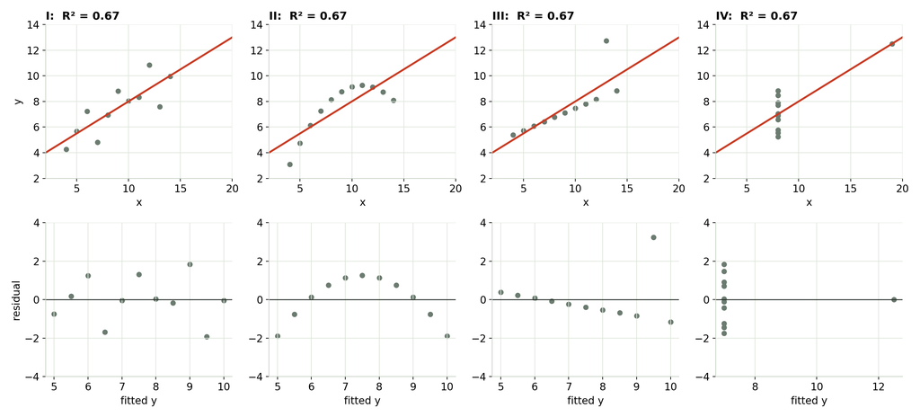

## R² can’t tell a good fit from a bad one

- R² = share of the scatter in y that the line accounts for.
- It says nothing about **shape**, **single points**, or whether a line was the right model at all.
- Look at the data and the residuals first. Module 2 shows what to look for.

## R² measures your test range

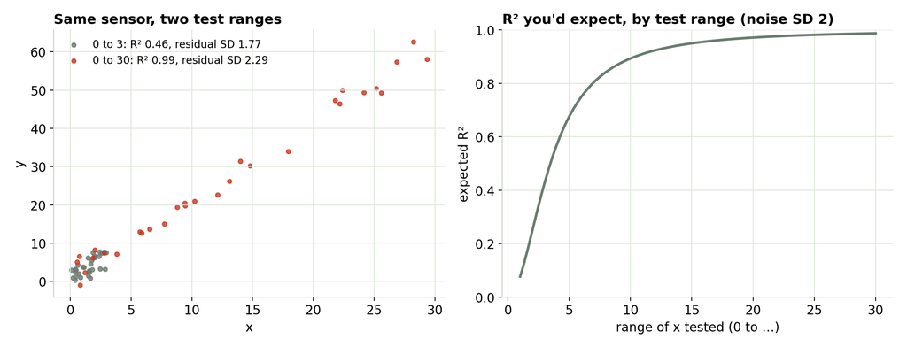

## Report the residual SD, in units

- Same noise, wider range → higher R². Nothing about the sensor changed.
- The **residual SD** says how far a single reading typically sits from the line, in real units.
- “s = 0.4 °C” means something. “R² = 0.998” doesn’t, on its own.

## More terms always raise R²

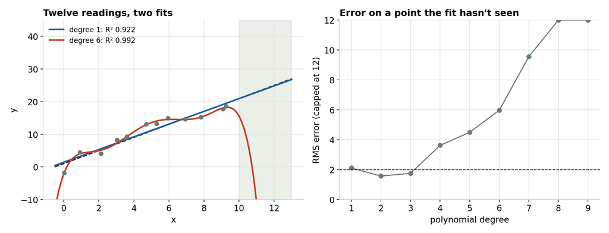

## Choose the model from the physics

- Every extra term raises R², even when it only fits noise.
- **Adjusted R²** charges for each term; **error on unseen points** (leave one out) shows what matters: prediction.
- Pick the shape the physics gives you. Check it with residual plots.

## Try it yourself

[interactive chart not shown]

The interactive loads from the page next to these slides. Open it in its own tab.

## What to take away

- R² can’t tell a good fit from a bad one. **Plot the data and the residuals.**
- R² grows with your test range. **Report the residual SD in units.**
- More terms always raise R². **Choose the model from the physics.**

Next: Module 2, reading a residual plot.